# Titanic Kaggle Competition

# Author: Andrew Barlow

## Import Packages

```python
%matplotlib inline
import numpy as np
import matplotlib.pyplot as plt
import pandas as pd
from sklearn import preprocessing
from sklearn.model_selection  import train_test_split, cross_val_score, KFold
from sklearn.model_selection import GridSearchCV
from sklearn.metrics import accuracy_score, precision_score, recall_score, f1_score
from sklearn.metrics import roc_curve, auc, confusion_matrix, classification_report
import os as os
import time
```

```python
%pwd
```

```
'C:\\Users\\Andrew\\Documents\\Pred_Models_git-master\\Week 8\\code'
```

```python
os.chdir("C:\\Users\\Andrew\\Documents\\Pred_Models_git-master\\Week 8")
```

```python
# Hide Warnings
from IPython.display import HTML
HTML('''<script>
code_show_err=false;
function code_toggle_err() {
 if (code_show_err){
 $('div.output_stderr').hide();
 } else {
 $('div.output_stderr').show();
 }
 code_show_err = !code_show_err
}
$( document ).ready(code_toggle_err);
</script>
To toggle on/off output_stderr, click <a href="javascript:code_toggle_err()">here</a>.''')
```

To toggle on/off output_stderr, click here.

## Read in Data

```python
train = pd.read_csv("data/train.csv")
test = pd.read_csv("data/test.csv")
```

```python
train.head()
```

|  | PassengerId | Survived | Pclass | Name | Sex | Age | SibSp | Parch | Ticket | Fare | Cabin | Embarked |
| --- | --- | --- | --- | --- | --- | --- | --- | --- | --- | --- | --- | --- |
| 0 | 1 | 0 | 3 | Braund, Mr. Owen Harris | male | 22.0 | 1 | 0 | A/5 21171 | 7.2500 | NaN | S |
| 1 | 2 | 1 | 1 | Cumings, Mrs. John Bradley (Florence Briggs Th... | female | 38.0 | 1 | 0 | PC 17599 | 71.2833 | C85 | C |
| 2 | 3 | 1 | 3 | Heikkinen, Miss. Laina | female | 26.0 | 0 | 0 | STON/O2. 3101282 | 7.9250 | NaN | S |
| 3 | 4 | 1 | 1 | Futrelle, Mrs. Jacques Heath (Lily May Peel) | female | 35.0 | 1 | 0 | 113803 | 53.1000 | C123 | S |
| 4 | 5 | 0 | 3 | Allen, Mr. William Henry | male | 35.0 | 0 | 0 | 373450 | 8.0500 | NaN | S |

## Preprocessing Features of the Data

```python
# Find the sum of missing values
print(train.isnull().sum())
```

```
PassengerId      0
Survived         0
Pclass           0
Name             0
Sex              0
Age            177
SibSp            0
Parch            0
Ticket           0
Fare             0
Cabin          687
Embarked         0
dtype: int64
```

Side Note: There were two missing values for Embarked in the training set and there were no missing values for Embarked in the testing set. I decided to randomly fill in one of the missing values with 'C' and the other with 'Q'. We know that using fake data can be problematic, but since there were only two missing values it should not effect our results by much.

```python
# Find the sum of missing values
print(test.isnull().sum())
```

```
PassengerId      0
Pclass           0
Name             0
Sex              0
Age             86
SibSp            0
Parch            0
Ticket           0
Fare             1
Cabin          327
Embarked         0
dtype: int64
```

We observe that there are missing values for age and cabbin in both the training and testing set. For age, me us ask ourselves: why are there missing values for age? Could it be that age is not reported for infants under the age of 1? Or are there just missing values that we can impute by the mean age. In this case I will assume the former and impute by the mean age. For cabin number we will create another class called 'None'.

```python
# Impute missing age values with the mean
train['Age'] = train['Age'].fillna(train['Age'].mean())
```

```python
# Impute missing age values with the mean
test['Age'] = test['Age'].fillna(test['Age'].mean())
```

```python
# Drop Name and Ticket from the training set because these categorical variables are difficult to deal with and may not be predictive
train = train.drop(['Name', 'Ticket'], axis = 1)
```

```python
train.head(5)
```

|  | PassengerId | Survived | Pclass | Sex | Age | SibSp | Parch | Fare | Cabin | Embarked |
| --- | --- | --- | --- | --- | --- | --- | --- | --- | --- | --- |
| 0 | 1 | 0 | 3 | male | 22.0 | 1 | 0 | 7.2500 | NaN | S |
| 1 | 2 | 1 | 1 | female | 38.0 | 1 | 0 | 71.2833 | C85 | C |
| 2 | 3 | 1 | 3 | female | 26.0 | 0 | 0 | 7.9250 | NaN | S |
| 3 | 4 | 1 | 1 | female | 35.0 | 1 | 0 | 53.1000 | C123 | S |
| 4 | 5 | 0 | 3 | male | 35.0 | 0 | 0 | 8.0500 | NaN | S |

```python
# Drop Name and Ticket from the Test set
test = test.drop(['Name', 'Ticket'], axis = 1)
```

```python
test.head(5)
```

|  | PassengerId | Pclass | Sex | Age | SibSp | Parch | Fare | Cabin | Embarked |
| --- | --- | --- | --- | --- | --- | --- | --- | --- | --- |
| 0 | 892 | 3 | male | 34.5 | 0 | 0 | 7.8292 | NaN | Q |
| 1 | 893 | 3 | female | 47.0 | 1 | 0 | 7.0000 | NaN | S |
| 2 | 894 | 2 | male | 62.0 | 0 | 0 | 9.6875 | NaN | Q |
| 3 | 895 | 3 | male | 27.0 | 0 | 0 | 8.6625 | NaN | S |
| 4 | 896 | 3 | female | 22.0 | 1 | 1 | 12.2875 | NaN | S |

```python
# Change the cabin variable to to be only the first letter or none
# These two code blocks were provided by: https://www.youtube.com/watch?v=0GrciaGYzV0

def clean_cabin(x):
    try:
        return x[0]
    except TypeError:
        return "None"

train["Cabin"] = train.Cabin.apply(clean_cabin)
```

```python
# Cleans categorical variables and creates dummies
categorical_variables = ['Sex', 'Cabin', 'Embarked']

for variable in categorical_variables:
    train[variable].fillna("Missing", inplace = True)
    dummies = pd.get_dummies(train[variable], prefix = variable)
    train = pd.concat([train, dummies], axis =1)
    train.drop([variable], axis =1, inplace = True)
```

```python
train.head(5)
```

|  | PassengerId | Survived | Pclass | Age | SibSp | Parch | Fare | Sex_female | Sex_male | Cabin_A | ... | Cabin_C | Cabin_D | Cabin_E | Cabin_F | Cabin_G | Cabin_None | Cabin_T | Embarked_C | Embarked_Q | Embarked_S |
| --- | --- | --- | --- | --- | --- | --- | --- | --- | --- | --- | --- | --- | --- | --- | --- | --- | --- | --- | --- | --- | --- |
| 0 | 1 | 0 | 3 | 22.0 | 1 | 0 | 7.2500 | 0 | 1 | 0 | ... | 0 | 0 | 0 | 0 | 0 | 1 | 0 | 0 | 0 | 1 |
| 1 | 2 | 1 | 1 | 38.0 | 1 | 0 | 71.2833 | 1 | 0 | 0 | ... | 1 | 0 | 0 | 0 | 0 | 0 | 0 | 1 | 0 | 0 |
| 2 | 3 | 1 | 3 | 26.0 | 0 | 0 | 7.9250 | 1 | 0 | 0 | ... | 0 | 0 | 0 | 0 | 0 | 1 | 0 | 0 | 0 | 1 |
| 3 | 4 | 1 | 1 | 35.0 | 1 | 0 | 53.1000 | 1 | 0 | 0 | ... | 1 | 0 | 0 | 0 | 0 | 0 | 0 | 0 | 0 | 1 |
| 4 | 5 | 0 | 3 | 35.0 | 0 | 0 | 8.0500 | 0 | 1 | 0 | ... | 0 | 0 | 0 | 0 | 0 | 1 | 0 | 0 | 0 | 1 |

5 rows × 21 columns

Vignette on Feature Engineering: The reason we are going through this process to clean the Cabin variable is that we believe it is an important factor in predicting if an individual survives or perishes on the Titanic. Our models may or may not find validity in this apriori assumption.

## Do the Same for the Testing Set

```python
# First impute the missing fare value by the mean
test['Fare'] = test['Fare'].fillna(test['Fare'].mean())
```

```python
# Clean the Cabin variable
test["Cabin"] = test.Cabin.apply(clean_cabin)
```

```python
# Apply the loop to create dummies
categorical_variables = ['Sex', 'Cabin', 'Embarked']

for variable in categorical_variables:
    test[variable].fillna("Missing", inplace = True)
    dummies = pd.get_dummies(test[variable], prefix = variable)
    test = pd.concat([test, dummies], axis =1)
    test.drop([variable], axis =1, inplace = True)
```

```python
test.head(5)
```

|  | PassengerId | Pclass | Age | SibSp | Parch | Fare | Sex_female | Sex_male | Cabin_A | Cabin_B | Cabin_C | Cabin_D | Cabin_E | Cabin_F | Cabin_G | Cabin_None | Embarked_C | Embarked_Q | Embarked_S |
| --- | --- | --- | --- | --- | --- | --- | --- | --- | --- | --- | --- | --- | --- | --- | --- | --- | --- | --- | --- |
| 0 | 892 | 3 | 34.5 | 0 | 0 | 7.8292 | 0 | 1 | 0 | 0 | 0 | 0 | 0 | 0 | 0 | 1 | 0 | 1 | 0 |
| 1 | 893 | 3 | 47.0 | 1 | 0 | 7.0000 | 1 | 0 | 0 | 0 | 0 | 0 | 0 | 0 | 0 | 1 | 0 | 0 | 1 |
| 2 | 894 | 2 | 62.0 | 0 | 0 | 9.6875 | 0 | 1 | 0 | 0 | 0 | 0 | 0 | 0 | 0 | 1 | 0 | 1 | 0 |
| 3 | 895 | 3 | 27.0 | 0 | 0 | 8.6625 | 0 | 1 | 0 | 0 | 0 | 0 | 0 | 0 | 0 | 1 | 0 | 0 | 1 |
| 4 | 896 | 3 | 22.0 | 1 | 1 | 12.2875 | 1 | 0 | 0 | 0 | 0 | 0 | 0 | 0 | 0 | 1 | 0 | 0 | 1 |

There is a problem in the training set where we have a category of Cabin_T that is present in the training set but not present in the testing set, so we must get rid of this column in order for our training and testing features to have the same dimensions.

```python
# Drop Cabin_T class column from the train set
train = train.drop(['Cabin_T'], axis = 1)
```

```python
train.shape
```

```
(891, 20)
```

```python
test.shape
```

```
(418, 19)
```

## A Touch of EDA

```python
# Move survived to first column of the training set

# designate target variable name as Survived
targetName = 'Survived'
targetSeries = train[targetName]
# remove target from current location and insert in collum 0
del train[targetName]
train.insert(0, targetName, targetSeries)
#reprint dataframe and see target is in position 0
train.head(5)
```

|  | Survived | PassengerId | Pclass | Age | SibSp | Parch | Fare | Sex_female | Sex_male | Cabin_A | Cabin_B | Cabin_C | Cabin_D | Cabin_E | Cabin_F | Cabin_G | Cabin_None | Embarked_C | Embarked_Q | Embarked_S |
| --- | --- | --- | --- | --- | --- | --- | --- | --- | --- | --- | --- | --- | --- | --- | --- | --- | --- | --- | --- | --- |
| 0 | 0 | 1 | 3 | 22.0 | 1 | 0 | 7.2500 | 0 | 1 | 0 | 0 | 0 | 0 | 0 | 0 | 0 | 1 | 0 | 0 | 1 |
| 1 | 1 | 2 | 1 | 38.0 | 1 | 0 | 71.2833 | 1 | 0 | 0 | 0 | 1 | 0 | 0 | 0 | 0 | 0 | 1 | 0 | 0 |
| 2 | 1 | 3 | 3 | 26.0 | 0 | 0 | 7.9250 | 1 | 0 | 0 | 0 | 0 | 0 | 0 | 0 | 0 | 1 | 0 | 0 | 1 |
| 3 | 1 | 4 | 1 | 35.0 | 1 | 0 | 53.1000 | 1 | 0 | 0 | 0 | 1 | 0 | 0 | 0 | 0 | 0 | 0 | 0 | 1 |
| 4 | 0 | 5 | 3 | 35.0 | 0 | 0 | 8.0500 | 0 | 1 | 0 | 0 | 0 | 0 | 0 | 0 | 0 | 1 | 0 | 0 | 1 |

```
Survived
0    549
1    342
dtype: int64
```

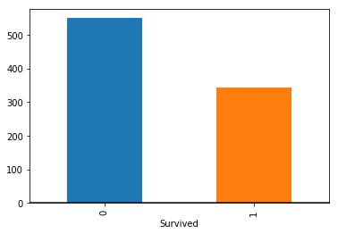

```python
# This chunk creates a bar chart to examine class balance
groupby = train.groupby(targetName)
targetEDA=groupby[targetName].aggregate(len)
plt.figure()
targetEDA.plot(kind='bar', grid=False)
plt.axhline(0, color='k')

train.groupby('Survived').size() # Prints the count of each class
```

We observe that the classes of survived is fairly balanced compared to the typical situation in classification problems. This is a good indication that our simple classification models may perform well on this data.

```python
# Descriptive statistics on numeric features
train.describe()
```

|  | Survived | PassengerId | Pclass | Age | SibSp | Parch | Fare | Sex_female | Sex_male | Cabin_A | Cabin_B | Cabin_C | Cabin_D | Cabin_E | Cabin_F | Cabin_G | Cabin_None | Embarked_C | Embarked_Q | Embarked_S |
| --- | --- | --- | --- | --- | --- | --- | --- | --- | --- | --- | --- | --- | --- | --- | --- | --- | --- | --- | --- | --- |
| count | 891.000000 | 891.000000 | 891.000000 | 891.000000 | 891.000000 | 891.000000 | 891.000000 | 891.000000 | 891.000000 | 891.000000 | 891.000000 | 891.000000 | 891.000000 | 891.000000 | 891.000000 | 891.000000 | 891.000000 | 891.000000 | 891.000000 | 891.000000 |
| mean | 0.383838 | 446.000000 | 2.308642 | 29.699118 | 0.523008 | 0.381594 | 32.204208 | 0.352413 | 0.647587 | 0.016835 | 0.052750 | 0.066218 | 0.037037 | 0.035915 | 0.014590 | 0.004489 | 0.771044 | 0.188552 | 0.087542 | 0.723906 |
| std | 0.486592 | 257.353842 | 0.836071 | 13.002015 | 1.102743 | 0.806057 | 49.693429 | 0.477990 | 0.477990 | 0.128725 | 0.223659 | 0.248802 | 0.188959 | 0.186182 | 0.119973 | 0.066890 | 0.420397 | 0.391372 | 0.282787 | 0.447315 |
| min | 0.000000 | 1.000000 | 1.000000 | 0.420000 | 0.000000 | 0.000000 | 0.000000 | 0.000000 | 0.000000 | 0.000000 | 0.000000 | 0.000000 | 0.000000 | 0.000000 | 0.000000 | 0.000000 | 0.000000 | 0.000000 | 0.000000 | 0.000000 |
| 25% | 0.000000 | 223.500000 | 2.000000 | 22.000000 | 0.000000 | 0.000000 | 7.910400 | 0.000000 | 0.000000 | 0.000000 | 0.000000 | 0.000000 | 0.000000 | 0.000000 | 0.000000 | 0.000000 | 1.000000 | 0.000000 | 0.000000 | 0.000000 |
| 50% | 0.000000 | 446.000000 | 3.000000 | 29.699118 | 0.000000 | 0.000000 | 14.454200 | 0.000000 | 1.000000 | 0.000000 | 0.000000 | 0.000000 | 0.000000 | 0.000000 | 0.000000 | 0.000000 | 1.000000 | 0.000000 | 0.000000 | 1.000000 |
| 75% | 1.000000 | 668.500000 | 3.000000 | 35.000000 | 1.000000 | 0.000000 | 31.000000 | 1.000000 | 1.000000 | 0.000000 | 0.000000 | 0.000000 | 0.000000 | 0.000000 | 0.000000 | 0.000000 | 1.000000 | 0.000000 | 0.000000 | 1.000000 |
| max | 1.000000 | 891.000000 | 3.000000 | 80.000000 | 8.000000 | 6.000000 | 512.329200 | 1.000000 | 1.000000 | 1.000000 | 1.000000 | 1.000000 | 1.000000 | 1.000000 | 1.000000 | 1.000000 | 1.000000 | 1.000000 | 1.000000 | 1.000000 |

## Set the Target and Features

```python
target_train=train['Survived']
features_train=train.drop(['Survived'], axis=1)
print(target_train.shape)
print(features_train.shape)
```

```
(891,)
(891, 19)
```

```python
# Define features of the test set
features_test = test
```

```python
features_test.head(5)
```

|  | PassengerId | Pclass | Age | SibSp | Parch | Fare | Sex_female | Sex_male | Cabin_A | Cabin_B | Cabin_C | Cabin_D | Cabin_E | Cabin_F | Cabin_G | Cabin_None | Embarked_C | Embarked_Q | Embarked_S |
| --- | --- | --- | --- | --- | --- | --- | --- | --- | --- | --- | --- | --- | --- | --- | --- | --- | --- | --- | --- |
| 0 | 892 | 3 | 34.5 | 0 | 0 | 7.8292 | 0 | 1 | 0 | 0 | 0 | 0 | 0 | 0 | 0 | 1 | 0 | 1 | 0 |
| 1 | 893 | 3 | 47.0 | 1 | 0 | 7.0000 | 1 | 0 | 0 | 0 | 0 | 0 | 0 | 0 | 0 | 1 | 0 | 0 | 1 |
| 2 | 894 | 2 | 62.0 | 0 | 0 | 9.6875 | 0 | 1 | 0 | 0 | 0 | 0 | 0 | 0 | 0 | 1 | 0 | 1 | 0 |
| 3 | 895 | 3 | 27.0 | 0 | 0 | 8.6625 | 0 | 1 | 0 | 0 | 0 | 0 | 0 | 0 | 0 | 1 | 0 | 0 | 1 |
| 4 | 896 | 3 | 22.0 | 1 | 1 | 12.2875 | 1 | 0 | 0 | 0 | 0 | 0 | 0 | 0 | 0 | 1 | 0 | 0 | 1 |

```python
features_test.shape
```

```
(418, 19)
```

# Decision Tree Classification Model

## DT #1

```python
# Decision Tree train model. Call up my model and name it clf_dt1
from sklearn import tree
clf_dt1 = tree.DecisionTreeClassifier(criterion='entropy', max_depth = 4)
#Fit clf to the training data
clf_dt1 = clf_dt1.fit(features_train, target_train)
#Predict clf DT model against test data
target_predicted_dt1 = clf_dt1.predict(features_test)
```

Since we do not have the target_test values, we will not be able to produce a classification and confusion matrix to gauge model performance. Instead, we can use cross validation to get a feel for the accuracy of the model. Since this competition uses accuracy as the sole metric of model performance, this is a good idea.

## Cross Validation of DT #1

```python
# Verify DT #1 with Cross Validation
scores1 = cross_val_score(clf_dt1, features_train, target_train, cv=10)
print("Cross Validation Score for each K",scores1)
scores1.mean()
```

```
Cross Validation Score for each K [0.7        0.78888889 0.78651685 0.85393258 0.83146067 0.7752809
 0.79775281 0.76404494 0.84269663 0.85227273]
```

```
0.7992847009420043
```

There is some variation in our accuracy scores, with the largest difference being 15%. This tells us that we are probably over-fitting. Next we will perform some grid searches to tune our decision tree for submission.

## DT #2

```python
# Experiment with some other parameters
clf_dt2 = tree.DecisionTreeClassifier(criterion='gini', class_weight = "balanced", max_depth = 2)
# Fit to the training data
clf_dt2 = clf_dt2.fit(features_train, target_train)
# Predict against test data
target_predicted_dt2 = clf_dt2.predict(features_test)
```

## Cross Validation of DT #2

```python
# Verify DT #2 with Cross Validation
scores2 = cross_val_score(clf_dt2, features_train, target_train, cv=10)
print("Cross Validation Score for each K",scores2)
scores2.mean()
```

```
Cross Validation Score for each K [0.77777778 0.73333333 0.76404494 0.75280899 0.79775281 0.74157303
 0.7752809  0.74157303 0.79775281 0.77272727]
```

```
0.7654624900692315
```

This model performs worse than the previous decision tree, a likely reason is that class_weight should not be set to "balanced". More tuning will be performed.

## DT #3

```python
clf_dt3 = tree.DecisionTreeClassifier(criterion='entropy', max_depth = 6, max_features = 10, min_samples_split = 4)
# Fit to the training data
clf_dt3 = clf_dt3.fit(features_train, target_train)
# Predict against test data
target_predicted_dt3 = clf_dt3.predict(features_test)
```

## Cross Validation of DT #3

```python
scores3 = cross_val_score(clf_dt3, features_train, target_train, cv=10)
print("Cross Validation Score for each K",scores3)
scores3.mean()
```

```
Cross Validation Score for each K [0.78888889 0.81111111 0.76404494 0.7752809  0.87640449 0.73033708
 0.79775281 0.79775281 0.83146067 0.84090909]
```

```
0.801394279877426
```

These are promising results that we are heading in the right direction in terms of lifting our accuracy score. The cross validation scores are more consistent with this model, meaning there is a smaller chance we are overfitting. Next we will perform a grid search on max_depth, min_samples_split, and max_features.

## Grid Search on DT Parameters

```python
start_time = time.clock()

param_grid = {"max_depth":[2, 4, 6, 8, 10], "max_features": [5, 10, 15, 19], "min_samples_split": [2, 4, 6, 8, 10]}

# run grid search
grid_search = GridSearchCV(clf_dt3, param_grid=param_grid,n_jobs=-1)

grid_search.fit(features_train, target_train)

# print(grid_search.cv_results_)
print("Best", grid_search.best_params_)

print("Time to run", time.clock() - start_time, "seconds")
```

```
Best {'max_depth': 6, 'max_features': 15, 'min_samples_split': 8}
Time to run 3.749552695999995 seconds
```

The grid search has determined the optimal value of the parameters, next we will substitute these values back into the model.

## Tuned DT #3

```python
clf_dt3 = tree.DecisionTreeClassifier(criterion='entropy', max_depth = 6, max_features = 15, min_samples_split = 8)
# Fit to the training data
clf_dt3 = clf_dt3.fit(features_train, target_train)
# Predict against test data
target_predicted_dt3 = clf_dt3.predict(features_test)
```

## Cross Validation of Tuned DT #3

```python
scores3 = cross_val_score(clf_dt3, features_train, target_train, cv=10)
print("Cross Validation Score for each K",scores3)
scores3.mean()
```

```
Cross Validation Score for each K [0.75555556 0.75555556 0.73033708 0.83146067 0.88764045 0.79775281
 0.82022472 0.79775281 0.85393258 0.85227273]
```

```
0.8082484961979344
```

We observe some lift in model accuracy, but we are probably over-fitting. Now that we have tuned the model, we can export the predictions for submission.

## Write Predictions to CSV

```python
features_test['Survived'] = pd.Series(target_predicted_dt3)
features_test.to_csv('submission_tuned_dt.csv', columns=["PassengerId", "Survived"], index=False)
```

# Random Forest Classifier

## RF #1

```python
# We must drop the old predictions from the features_test data frame
features_test = features_test.drop(['Survived'], axis = 1)
```

```python
# train random forest model
# paralleized to 4 cores
from sklearn.ensemble import RandomForestClassifier
rf1 = RandomForestClassifier(n_estimators= 100, criterion = 'entropy',  n_jobs=-1,
                             oob_score=True, max_depth = 6, max_features = 10, min_samples_split = 4)
rf1 = rf1.fit(features_train, target_train)
# test random forest model
target_predicted_rf1 = rf1.predict(features_test)
```

## Cross Validation of RF #1

```python
scores_rf1 = cross_val_score(rf1, features_train, target_train, cv=10, n_jobs=-1)
print("Cross Validation Score for each K",scores_rf1)
scores_rf1.mean()
```

```
Cross Validation Score for each K [0.77777778 0.85555556 0.7752809  0.84269663 0.85393258 0.84269663
 0.82022472 0.7752809  0.86516854 0.86363636]
```

```
0.8272250595846101
```

We observe that we are getting a good amount of lift compared to the decision tree model. Next we will experiment with some other parameter values and perform a grid search.

## Grid Search on RF Parameters

```python
start_time = time.clock()

param_grid = {"n_estimators":[50, 100, 150, 200, 500], "max_depth":[2, 4, 6, 8, 10], "max_features": [5, 10, 15, 19], "min_samples_split": [2, 4, 6, 8, 10]}

# run grid search
grid_search = GridSearchCV(rf1, param_grid=param_grid,n_jobs=-1)

grid_search.fit(features_train, target_train)

# print(grid_search.cv_results_)
print("Best", grid_search.best_params_)

print("Time to run", time.clock() - start_time, "seconds")
```

```
Best {'max_depth': 10, 'max_features': 10, 'min_samples_split': 2, 'n_estimators': 200}
Time to run 335.88889916200014 seconds
```

## RF #2 With Tuned Parameters

```python
# Alter the parameters
rf2 = RandomForestClassifier(n_estimators= 200, criterion = 'entropy', n_jobs=-1, oob_score=True,
                             max_depth = 10, max_features = 10, min_samples_split = 2)
# Fit the model
rf2 = rf2.fit(features_train, target_train)
# Test random forest model
target_predicted_rf2 = rf2.predict(features_test)
```

## Cross Validation of RF #2

```python
scores_rf2 = cross_val_score(rf2, features_train, target_train, cv=10, n_jobs=-1)
print("Cross Validation Score for each K",scores_rf2)
scores_rf2.mean()
```

```
Cross Validation Score for each K [0.77777778 0.81111111 0.76404494 0.85393258 0.8988764  0.84269663
 0.83146067 0.83146067 0.85393258 0.81818182]
```

```
0.8283475201452729
```

We observe some lift in the accuracy scores, but we are probably overfitting due to the large difference in some of the accuracy scores. Next we will output the results to CSV.

```python
# Let's take a moment to examine feature importance
print("Features sorted by their score:")
print("Higher the more important")
print(sorted(zip(map(lambda x: round(x, 4), rf2.feature_importances_),features_test.columns[:19]),
             reverse=True))
```

[output not shown]

## Write Predictions to CSV

```python
features_test['Survived'] = pd.Series(target_predicted_rf2)
features_test.to_csv('submission_tuned_rf.csv', columns=["PassengerId", "Survived"], index=False)
```

# Linear Support Vector Machines

## Linear SVM #1

```python
# Drop old predictions
features_test = features_test.drop(['Survived'], axis = 1)
```

```python
start_time = time.clock()
from sklearn.svm import LinearSVC
# standard linear SVC
clf_linSVC1 = LinearSVC(penalty='l2', loss='squared_hinge', dual=True, tol=0.0001, C=1.0)
clf_linSVC1.fit(features_train, target_train)
predicted_linSVM1=clf_linSVC1.predict(features_test)
print("Time to run", time.clock() - start_time, "seconds")
```

```
Time to run 0.5993609340002877 seconds
```

## Cross Validation of Linear SVM #1

```python
scores_linSVC1 = cross_val_score(clf_linSVC1, features_train, target_train, cv=10, n_jobs=-1)
print("Cross Validation Score for each K",scores_linSVC1)
scores_linSVC1.mean()
```

```
Cross Validation Score for each K [0.78888889 0.74444444 0.47191011 0.75280899 0.6741573  0.75280899
 0.76404494 0.40449438 0.38202247 0.38636364]
```

```
0.6121944160708205
```

These results are troubling considering that the accuracy scores vary dramatically. This tells us that our data may not be linearly seperable. We will experiment with some other parameter values to see if we can improve the accuracy of our linear svm.

## Linear SVM #2

```python
clf_linSVC2 = LinearSVC(penalty='l1', loss='squared_hinge', dual=False, tol=0.0001, C=3.0)
clf_linSVC2.fit(features_train, target_train)
predicted_linSVM2=clf_linSVC2.predict(features_test)
```

## Cross Validation of Linear SVM #2

```python
scores_linSVC2 = cross_val_score(clf_linSVC2, features_train, target_train, cv=10, n_jobs=-1)
print("Cross Validation Score for each K",scores_linSVC2)
scores_linSVC2.mean()
```

```
Cross Validation Score for each K [0.77777778 0.77777778 0.7752809  0.85393258 0.78651685 0.7752809
 0.79775281 0.78651685 0.84269663 0.77272727]
```

```
0.7946260356372716
```

This is a drastic improvement in our accuracy results, and they are more consistent as well. Next we will perform a grid search to further tune our linear support vector machine model.

## Grid Search on Linear SVM Parameters

```python
start_time = time.clock()

param_grid = {"penalty":['l1', 'l2'], "tol": [0.00001, 0.0001, 0.001], "C":[0.5, 1.0, 2.0, 3.0, 5.0]}

# run grid search
grid_search = GridSearchCV(clf_linSVC2, param_grid=param_grid,n_jobs=-1)

grid_search.fit(features_train, target_train)

# print(grid_search.cv_results_)
print("Best", grid_search.best_params_)

print("Time to run", time.clock() - start_time, "seconds")
```

```
Best {'C': 3.0, 'penalty': 'l2', 'tol': 0.001}
Time to run 0.6039688040000328 seconds
```

## Linear SVM #3 With Tuned Parameters

```python
clf_linSVC3 = LinearSVC(penalty='l2', loss='squared_hinge', dual=False, tol=0.001, C=3.0)
clf_linSVC3.fit(features_train, target_train)
predicted_linSVM3=clf_linSVC3.predict(features_test)
```

## Cross Validation of Tuned Linear SVM

```python
scores_linSVC3 = cross_val_score(clf_linSVC3, features_train, target_train, cv=10, n_jobs=-1)
print("Cross Validation Score for each K",scores_linSVC2)
scores_linSVC3.mean()
```

```
Cross Validation Score for each K [0.77777778 0.77777778 0.7752809  0.85393258 0.78651685 0.7752809
 0.79775281 0.78651685 0.84269663 0.77272727]
```

```
0.7968607422540006
```

We observe some lift in the model when experimenting with different parameter values. We can now export the results for submission.

## Export Predictions

```python
features_test['Survived'] = pd.Series(predicted_linSVM3)
features_test.to_csv('submission_tuned_LinSVM2.csv', columns=["PassengerId", "Survived"], index=False)
```

# SVM RBF

```python
# Drop old Predictions
features_test = features_test.drop(['Survived'], axis = 1)
```

## SVM RBF #1

```python
start_time = time.clock()
from sklearn.svm import SVC
# standard non-linear SVC
clf_rbf1 = SVC(kernel='rbf', C=1.0, degree=3, class_weight= None, gamma= 'auto')
clf_rbf1.fit(features_train, target_train)
predicted_rbf1=clf_rbf1.predict(features_test)
print("Time to run", time.clock() - start_time, "seconds")
```

```
Time to run 0.13008834699576255 seconds
```

## Cross Validation of RBF #1

```python
scores_svm1 = cross_val_score(clf_rbf1, features_train, target_train, cv=10, n_jobs=-1)
print("Cross Validation Score for each K",scores_svm1)
scores_svm1.mean()
```

```
Cross Validation Score for each K [0.62222222 0.62222222 0.59550562 0.5505618  0.57303371 0.61797753
 0.60674157 0.60674157 0.60674157 0.61363636]
```

```
0.6015384178867325
```

These results are below average compared to the other models, we will experiment with the penalty parameter as well as different degrees of the kernel function.

## RBF #2

```python
# standard non-linear SVC
clf_rbf2 = SVC(kernel='rbf', C=3.0, degree=4, class_weight= None, gamma= 0.052)
clf_rbf2.fit(features_train, target_train)
predicted_rbf2=clf_rbf2.predict(features_test)
```

## Cross Validation of RBF #2

```python
scores_svm2 = cross_val_score(clf_rbf2, features_train, target_train, cv=10, n_jobs=-1)
print("Cross Validation Score for each K",scores_svm2)
scores_svm2.mean()
```

```
Cross Validation Score for each K [0.61111111 0.63333333 0.57303371 0.50561798 0.57303371 0.61797753
 0.60674157 0.59550562 0.59550562 0.61363636]
```

```
0.5925496538417886
```

## Grid Search on Degree and Penalty Parameter

```python
param_grid = {'C':[.001,.01,1,3,5,10], "degree": [2,3,4,5,6,7]}

# run grid search
grid_search = GridSearchCV(clf_rbf2, param_grid=param_grid,n_jobs=-1)

grid_search.fit(features_train, target_train)

# print(grid_search.cv_results_)
print("Best", grid_search.best_params_)
```

```
Best {'C': 0.001, 'degree': 2}
```

## RBF #3 With Tuned Parameters

```python
clf_rbf3 = SVC(kernel='rbf', C=0.001, degree=2, class_weight= None, gamma= 0.052)
clf_rbf3.fit(features_train, target_train)
predicted_rbf3=clf_rbf3.predict(features_test)
```

## Cross Validation of Tuned RBF

```python
scores_svm3 = cross_val_score(clf_rb3, features_train, target_train, cv=10, n_jobs=-1)
print("Cross Validation Score for each K",scores_svm3)
scores_svm3.mean()
```

[output not shown]

[output not shown]

Again we are not observing much lift in the accuracy scores of the model. We will not include this model in submission as it does not perform well enough.

# Bagging Classifier

## Bagging Classifier #1

```python
# Let's see if we can improve the performance of a decision tree using bagging
from sklearn.ensemble import BaggingClassifier
clf_bag1 = BaggingClassifier(base_estimator = tree.DecisionTreeClassifier(), n_estimators=200, max_samples = 0.5,
                             max_features = 0.5 )

clf_bag1.fit(features_train, target_train)
predicted_bag1=clf_bag1.predict(features_test)
```

## Cross Validation of Bagging Classifier #1

```python
scores_bag1 = cross_val_score(clf_bag1, features_train, target_train, cv=10, n_jobs=-1)
print("Cross Validation Score for each K",scores_bag1)
scores_bag1.mean()
```

```
Cross Validation Score for each K [0.8        0.78888889 0.79775281 0.83146067 0.86516854 0.83146067
 0.82022472 0.78651685 0.83146067 0.82954545]
```

```
0.8182479287254567
```

We observe that we are getting consistent accuracy scores, so we are confident that this model is not overfitting. Let's see if we can further tune the model to gain some lift in accuracy.

## Grid Search on Bagging Parameters

```python
param_grid = {"n_estimators":[50, 100, 150, 200, 250],"max_samples":[0.1,0.3,0.5,0.7,1.0], "max_features": [0.1,0.3,0.5,0.7,1.0]}

# run grid search
grid_search = GridSearchCV(clf_bag1, param_grid=param_grid,n_jobs=-1)

grid_search.fit(features_train, target_train)

# print(grid_search.cv_results_)
print("Best", grid_search.best_params_)
```

```
Best {'max_features': 0.7, 'max_samples': 0.3, 'n_estimators': 100}
```

## Bagging Classifier #2 With Tuned Parameters

```python
clf_bag2 = BaggingClassifier(base_estimator = tree.DecisionTreeClassifier(), n_estimators=100, max_samples = 0.3,
                             max_features = 0.7 )

clf_bag2.fit(features_train, target_train)
predicted_bag2=clf_bag2.predict(features_test)
```

## Cross Validation of Tuned Bagging Classifier

```python
scores_bag2 = cross_val_score(clf_bag2, features_train, target_train, cv=10, n_jobs=-1)
print("Cross Validation Score for each K",scores_bag2)
scores_bag2.mean()
```

```
Cross Validation Score for each K [0.78888889 0.8        0.7752809  0.83146067 0.87640449 0.84269663
 0.82022472 0.79775281 0.86516854 0.84090909]
```

```
0.8238786743842924
```

We observe some lift in the accuracy mean compared to the other bagging classifier, so we are confident that this model will not overfit and may perform well on the testing set. Next we will output the results to a csv for submission on Kaggle.

## Write Predictions to CSV

```python
features_test['Survived'] = pd.Series(predicted_bag2)
features_test.to_csv('submission_tuned_bag.csv', columns=["PassengerId", "Survived"], index=False)
```

Note: This model jumped our position on the leaderboard by 2,000 places! Let's continue to experiment with ensembles.